# Maths Analisys

Yesid López - Mario Micolta - Daniel Gutiérrez

3/22/2020

# Introduccion

Para el ICFES es muy importante conocer cuáles son los factores de éxito en el desempeño en un curso de matemáticas de estudiantes de grado 10mo.

El presente informe, tiene como objetivo presentar las características de los datos de estudiantes de grado 10mo que incluye su desempeño el curso de matemáticas.

Los datos fueron recolectados en un colegio a través del seguimiento del rendimiento académico en el curso de matemáticas.

Inicialmente se presentarán los detalles de la estructura de la base de datos, donde se detallará aspectos como el significado de cada fila y columna, los tipos de variable. Seguido de los detalles de la base de datos, expondremos los hallazgos más importantes en el análisis descriptivo univariado y bivariado y el tratamiento que les dimos. Por último, se listarán una serie de conclusiones y recomendaciones teniendo en cuenta los hallazgos encontrados en los datos.

# Hallazgos

## Limpieza de datos

Antes de empezar se cambia el formato de los datos:

| sex | age | address | Pstatus | Medu | Fedu | reason | traveltime | paid | internet | absences | G3 |
| --- | --- | --- | --- | --- | --- | --- | --- | --- | --- | --- | --- |
| Femenino | 18 | Urbano | Separados | higher education | higher education | course | 15 to 30 min. | no | no | 6 to 10 absences | 6 |
| Femenino | 17 | Urbano | Viviendo juntos | none or primary education (4th grade) | none or primary education (4th grade) | course | <15 min. | no | yes | 0 to 5 absences | 6 |
| Femenino | 15 | Urbano | Viviendo juntos | none or primary education (4th grade) | none or primary education (4th grade) | other | <15 min. | yes | yes | 6 to 10 absences | 10 |
| Femenino | 15 | Urbano | Viviendo juntos | higher education | 5th to 9th grade | home | <15 min. | yes | yes | 0 to 5 absences | 15 |
| Femenino | 16 | Urbano | Viviendo juntos | secondary education | secondary education | home | <15 min. | yes | no | 0 to 5 absences | 10 |
| Masculino | 16 | Urbano | Viviendo juntos | higher education | secondary education | reputation | <15 min. | yes | yes | 6 to 10 absences | 15 |

## Exploración de los datos

El objetivo de esta sección es mostrar los hallazgos **más relevantes** del análisis univariado y su relación con la variable dependiente. Esto con el objetivo de dar un vistaso de las variables, mirar su distribución y encontrar si realmente tienen relación:

### Analisis Univariado

#### Cualitativo

##### Nivel de educacion de la madre

| var | frequency | percentage | cumulative_perc |
| --- | --- | --- | --- |
| higher education | 125 | 35.01 | 35.01 |
| secondary education | 90 | 25.21 | 60.22 |
| 5th to 9th grade | 89 | 24.93 | 85.15 |
| none or primary education (4th grade) | 53 | 14.85 | 100.00 |

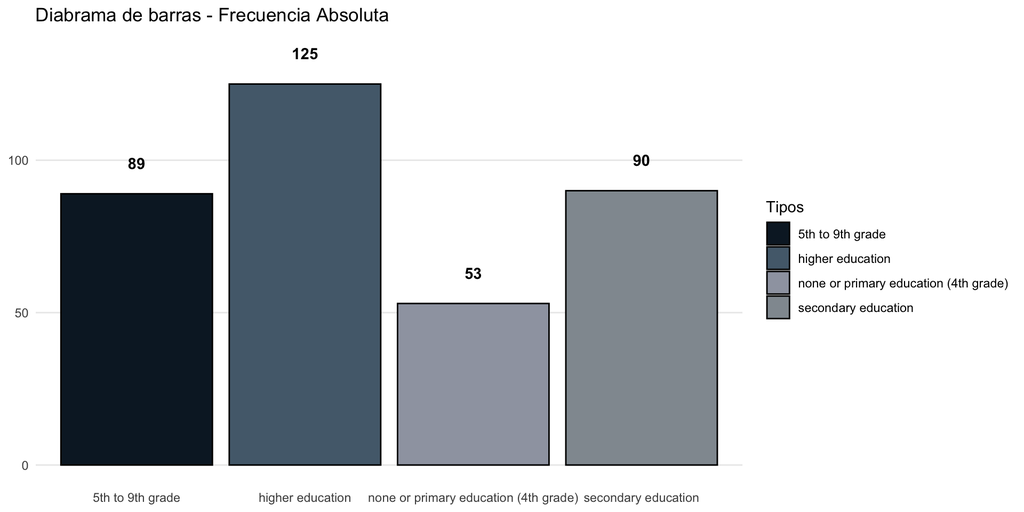

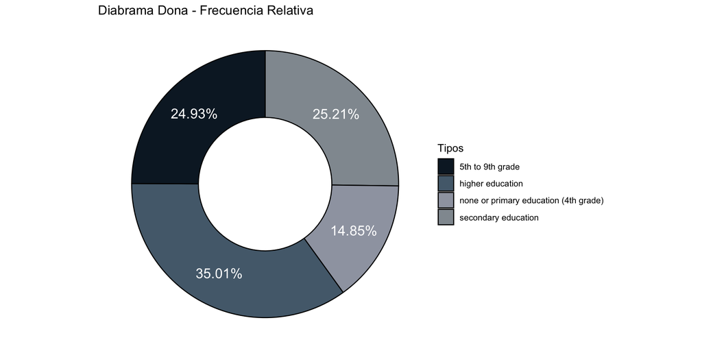

##### Nivel de educacion del padre

| var | frequency | percentage | cumulative_perc |
| --- | --- | --- | --- |
| 5th to 9th grade | 102 | 28.57 | 28.57 |
| secondary education | 94 | 26.33 | 54.90 |
| higher education | 88 | 24.65 | 79.55 |
| none or primary education (4th grade) | 73 | 20.45 | 100.00 |

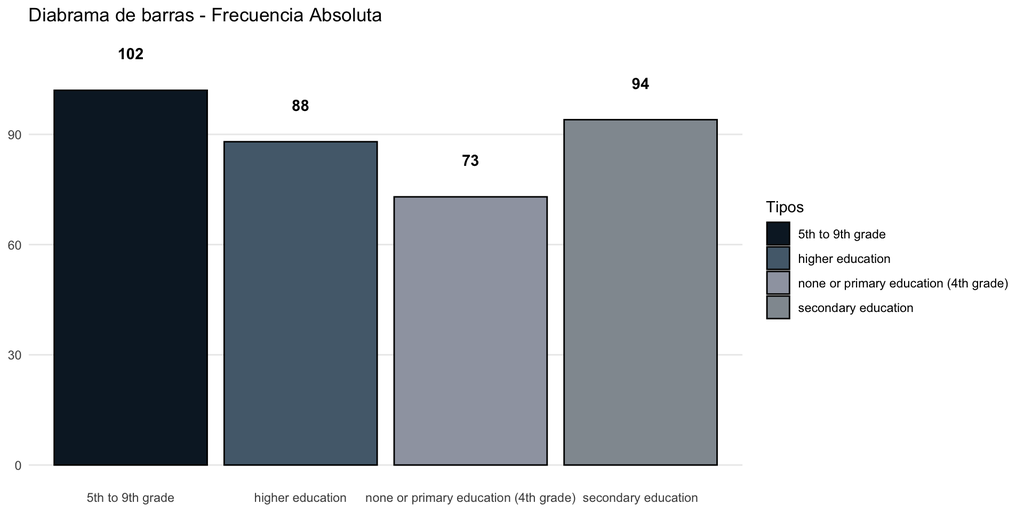

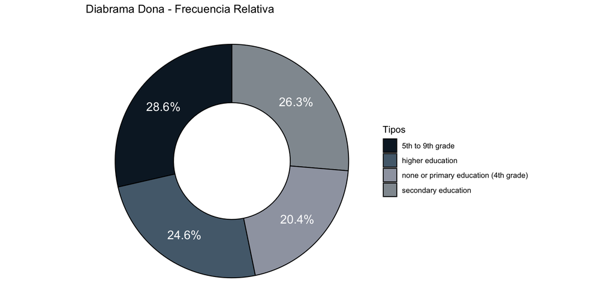

##### Tiempo de viaje de la casa a la escuela

| var | frequency | percentage | cumulative_perc |
| --- | --- | --- | --- |
| <15 min. | 236 | 66.11 | 66.11 |
| 15 to 30 min. | 95 | 26.61 | 92.72 |
| >30 min. | 26 | 7.28 | 100.00 |

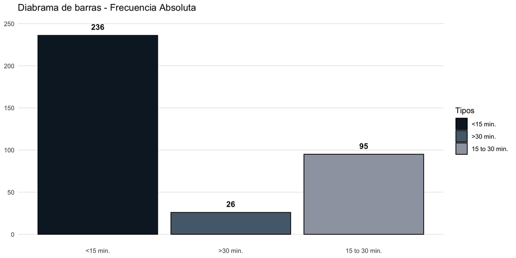

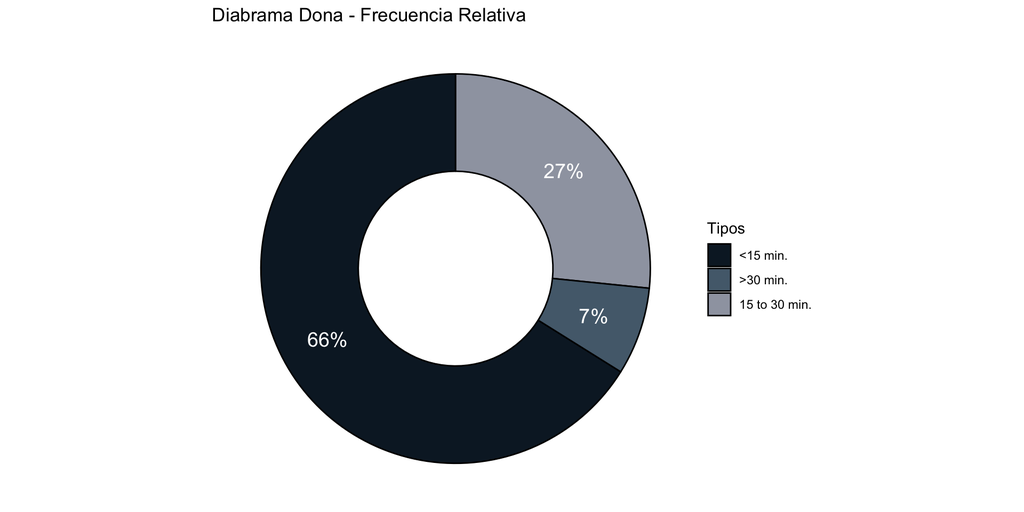

##### Clases extra pagadas

| var | frequency | percentage | cumulative_perc |
| --- | --- | --- | --- |
| no | 184 | 51.54 | 51.54 |
| yes | 173 | 48.46 | 100.00 |

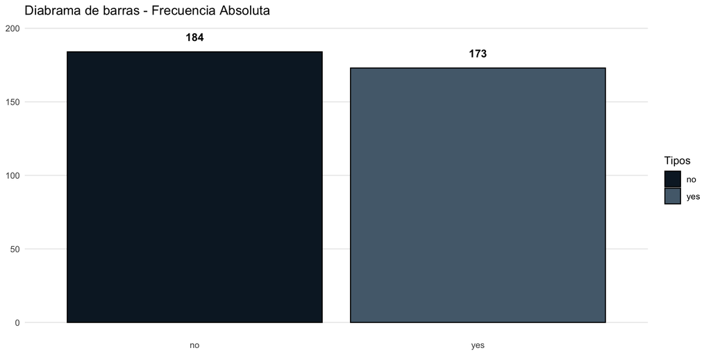

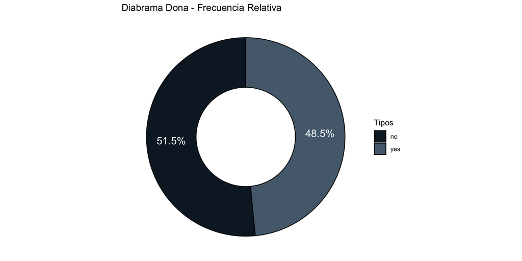

# Analisis Bivariado

Al momento de analizar las relaciones entre variables cuantitativas y cualitativas se debe verificar que los datos cumplan una distribucion normal, dependiendo de esto se pueden tomar diferentes caminos para probar igualdad de medias entre diferentes tratamientos. A continuacion evaluamos la normalidad de la variable G3.

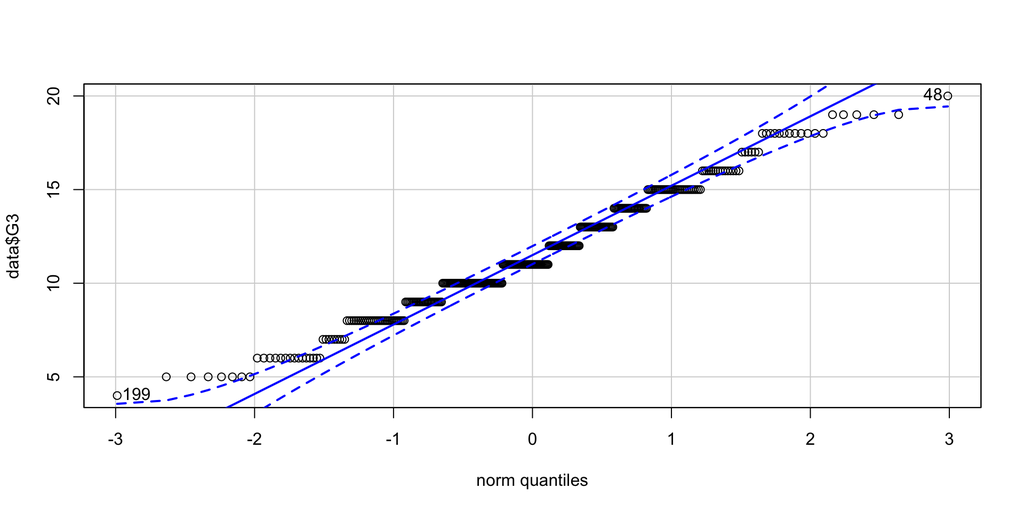

[1] 48 199

Como se ve en el grafico algunos puntos se ven fueras de los rangos, lo cual puede significa que no se cumple normalidad. Para validar esto se puede hacer un prueba de Shapiro Shapiro-Wilk normality test

data: data$G3 W = 0.98082, p-value = 0.000109

Dado que el valor p es menor a 0.05 se rechaza la hipotesis nula de normalidad en la distribucion de los datos Anderson-Darling normality test

data: data$G3 A = 2.5143, p-value = 2.323e-06

Seguido se realiza la prueba de Anderson-Darling, dado que el valor p es menor a 0.05 se rechaza la hipotesis nula de normalidad en la distribucion de los datos.

Tenemos entonces mayor certeza al descartar el supuesto de normalidad en los datos.

## Nivel de educacion de la madre vs notas finales

Dado que no se cumple normalidad podriamos realizar un analisis de igualdad de medias con la prueba de Kruskal-Wallis.

```
##                                  category   n    mean     sd median trimmed
## G31 none or primary education (4th grade)  53 10.3962 2.5969     10 10.3488
## G32                      5th to 9th grade  89 11.2584 2.7367     11 11.1644
## G33                   secondary education  90 11.3333 3.4250     11 11.2361
## G34                      higher education 125 12.3280 3.4752     13 12.3465
##        mad min max range    skew kurtosis     se  IQR Q0.25 Q0.75
## G31 2.9652   5  16    11  0.1388  -0.2456 0.3567 3.00     9 12.00
## G32 2.9652   6  19    13  0.3303  -0.0589 0.2901 3.00    10 13.00
## G33 2.9652   5  19    14  0.2696  -0.5994 0.3610 4.75     9 13.75
## G34 4.4478   4  20    16 -0.0966  -0.6360 0.3108 5.00    10 15.00
```

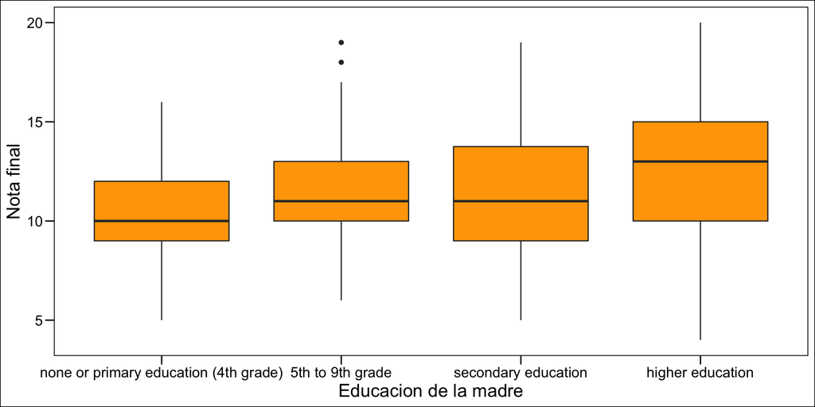

Vemos que visualmente entre las diferentes tratamientos hay diferencias, para verificar esto estadisticamente procedemos a realizar una prueba de Kruskal-Wallis. Esta prueba verifica la igual entre las medias de las diferentes poblaciones.

```
##
##  Kruskal-Wallis rank sum test
##
## data:  G3 by Medu
## Kruskal-Wallis chi-squared = 14.821, df = 3, p-value = 0.001976
```

Como el valor p es menor a 0.05 se puede decir con un nivel de signficancia de 95% que existe diferencia significativa entre las medias de los grupos. Es decir, esta prueba corrobora con un nivel de significancia de 95% que el nivel educativo de la madre (Medu) influye sobre las notas finales. Dado que se rechazo la hipotesis nula de la prueba se puede realizar la prueba de Wilcox para identificar cuales son las medias diferentes.

```
##
##  Pairwise comparisons using Wilcoxon rank sum test
##
## data:  Medu_G3$G3 and Medu_G3$Medu
##
##                     none or primary education (4th grade) 5th to 9th grade
## 5th to 9th grade    0.2288                                -
## secondary education 0.2805                                0.9491
## higher education    0.0024                                0.0640
##                     secondary education
## 5th to 9th grade    -
## secondary education -
## higher education    0.1309
##
## P value adjustment method: holm
```

```
##                     none or primary education (4th grade) 5th to 9th grade
## 5th to 9th grade                                    FALSE               NA
## secondary education                                 FALSE            FALSE
## higher education                                     TRUE            FALSE
##                     secondary education
## 5th to 9th grade                     NA
## secondary education                  NA
## higher education                  FALSE
```

Al utilizar la prueba wilcox para identificar las medias diferentes se puede decir con un nivel de confiabilidad de 95% que son estadisticamente diferentes las medias entre higher education y none or primary education (4th grade). Es decir la media de notas finales de los estudiantes con madres con educacion universitaria son diferentes a las notas de los estudiantes con madres con educacion nula o primaria.

## Nivel de educacion del padre vs notas finales

Dado que no se cumple normalidad podriamos realizar un analisis de igualdad de medias con la prueba de Kruskal-Wallis.

```
##     item                              category vars   n    mean     sd median
## G31    1 none or primary education (4th grade)    1  73 10.6438 3.0063   10.0
## G32    2                      5th to 9th grade    1 102 11.5686 3.1639   11.0
## G33    3                   secondary education    1  94 11.3404 3.2447   11.0
## G34    4                      higher education    1  88 12.3977 3.2889   12.5
##     trimmed    mad min max range    skew kurtosis     se IQR Q0.25 Q0.75
## G31 10.5085 2.9652   5  18    13  0.4026  -0.3891 0.3519   4     8    12
## G32 11.5366 2.9652   5  19    14  0.1636  -0.2861 0.3133   4    10    14
## G33 11.1842 2.9652   4  20    16  0.4075  -0.2874 0.3347   4     9    13
## G34 12.4583 3.7065   5  19    14 -0.1595  -0.4848 0.3506   5    10    15
```

[figure not shown]

Vemos que visualmente entre las diferentes tratamientos hay diferencias, para verificar esto estadisticamente procedemos a realizar una prueba de Kruskal-Wallis. Esta prueba verifica la igual entre las medias de las diferentes poblaciones.

```
##
##  Kruskal-Wallis rank sum test
##
## data:  G3 by Fedu
## Kruskal-Wallis chi-squared = 13.83, df = 3, p-value = 0.003146
```

De igual manera, para este analisis como el valor p es menor a 0.05 se puede decir con un nivel de signficancia de 95% que existe diferencia significativa entre las medias de los grupos. Es decir, esta prueba corrobora con un nivel de significancia de 95% que el nivel educativo del padre (Fedu) influye sobre las notas finales. Posteriormente se puede realizar una prueba de Wilcox para identificar las medias diferentes

```
##
##  Pairwise comparisons using Wilcoxon rank sum test
##
## data:  Fedu_G3$G3 and Fedu_G3$Fedu
##
##                     none or primary education (4th grade) 5th to 9th grade
## 5th to 9th grade    0.1737                                -
## secondary education 0.3906                                0.4431
## higher education    0.0023                                0.1760
##                     secondary education
## 5th to 9th grade    -
## secondary education -
## higher education    0.0688
##
## P value adjustment method: holm
```

```
##                     none or primary education (4th grade) 5th to 9th grade
## 5th to 9th grade                                    FALSE               NA
## secondary education                                 FALSE            FALSE
## higher education                                     TRUE            FALSE
##                     secondary education
## 5th to 9th grade                     NA
## secondary education                  NA
## higher education                  FALSE
```

En el resultado de la prueba wilcox se puede identificar las medias estadisticamente diferentes con un nivel de confiabilidad de 95%. Vemos que las medias entre higher education y none or primary education (4th grade) tiene valor menor a 0.05 por tanto son diferentes. Es decir la media de notas finales de los estudiantes con padres con educacion universitaria son diferentes a las notas de los estudiantes con padres con educacion nula o primaria.